# Two column ggplot2 charts

# Intro

Often you’ll want to arrange multiple {ggplot2} charts together with tags and titles, eg:

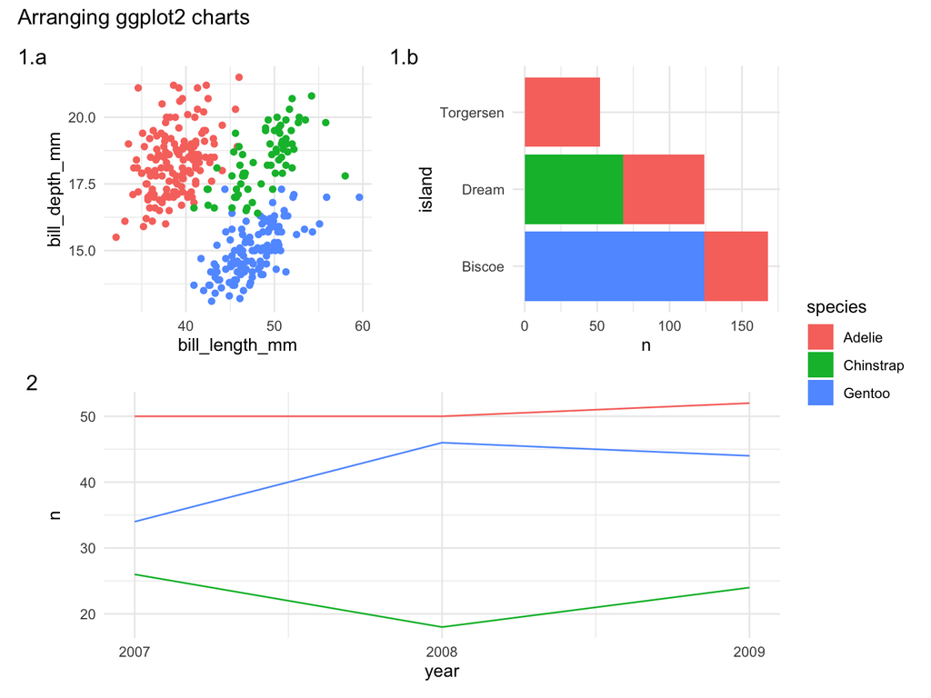

# cowplot vs patchwork

There are two different packages you can choose from, {cowplot} and {patchwork}. They are both very popular in the R community and it’s almost down to personal choice which one you prefer. I’ve tried to differentiate them a little bit:

# {cowplot}

- Charts are explicitly built within a grid using `plot_grid()`. The layout is controlled by specifying the number of rows and columns in the chart
- Nested `plot_grid()` are required to get a single chart to span multiple rows or columns.
- Themes need to be applied to individual charts.
- Legends need to be extracted from charts and manually placed within a `plot_grid()`.

> {cowplot} allows extreme precision over your charts. Complex collections of charts with inset charts and custom looking legends can be created.

# {patchwork}

- Charts are built using `(p1 + p2) / p3` syntax, `p3` will be placed under `p1` and `p2`.
- Because there is no grid system `p3` will automatically span the entire width of the chart.
- Themes can be applied to the entire patchwork chart.
- Legends can be automatically collected.

> {patchwork} feels and behaves like a ggplot2 extension, a lot of things are automated. It can become painful to create extremely customised charts.

# cowplot

We need to create a nested plot_grid() for the timeline chart to span the width of the chart:

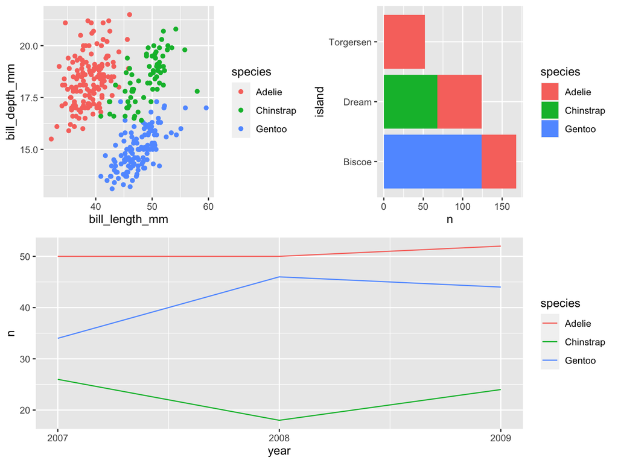

```r
plot_grid(plot_grid(gg_penguin_scatter, gg_penguin_bar_chart),
          plot_grid(gg_penguins_timeline),
          nrow = 2)
```

In the chart below our goal is to collect together the legends and change the theme:

- The legend is extracted from the bar chart with `get_legend()`
- The legends for all charts are disabled with `theme(legend.position = "none")`
- The legend is attached to the chart using another `plot_grid()`
- The theme has to be changed for all individual charts.

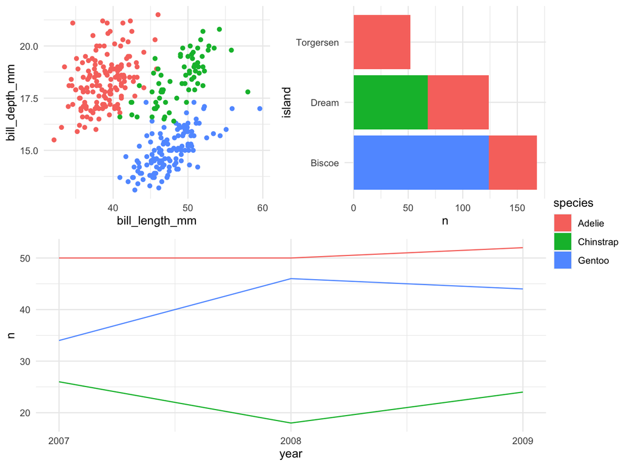

```r
cwp_legend <- get_legend(gg_penguin_bar_chart)

cwp_collected <-
  plot_grid(
    plot_grid(
      gg_penguin_scatter + theme_minimal() + theme(legend.position = "none"),
      gg_penguin_bar_chart + theme_minimal() + theme(legend.position = "none")
    ),
    plot_grid(gg_penguins_timeline + theme_minimal() + theme(legend.position = "none")),
    nrow = 2
  )

plot_grid(
  cwp_collected,
  cwp_legend,
  ncol = 2,
  rel_widths = c(8, 1)
)
```

Automatic labelling only works within an individual `plot_grid()`. We therefore need to add manual labels into the chart:

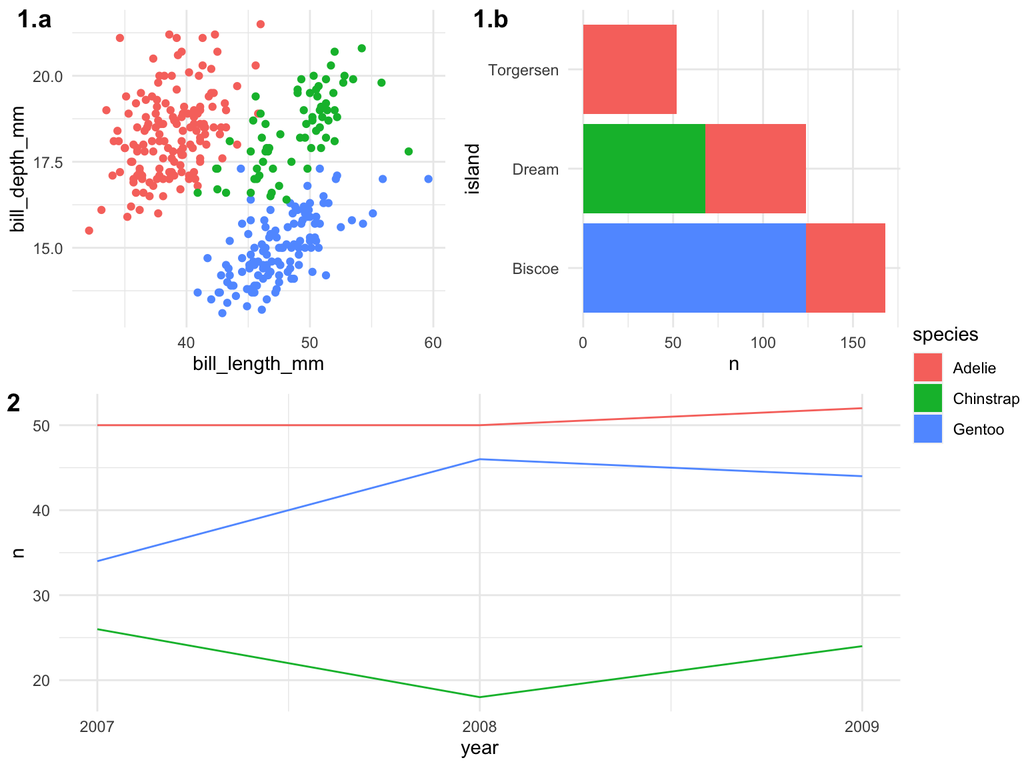

```r
cwp_labelled <-
  plot_grid(
    plot_grid(
      gg_penguin_scatter + theme_minimal() + theme(legend.position = "none"),
      gg_penguin_bar_chart + theme_minimal() + theme(legend.position = "none"),
      labels = c("1.a", "1.b")
    ),
    plot_grid(gg_penguins_timeline + theme_minimal() + theme(legend.position = "none"),
              labels = "2"),
    nrow = 2
  )

plot_grid(
  cwp_labelled,
  cwp_legend,
  ncol = 2,
  rel_widths = c(8, 1)
)
```

# Patchwork

Our basic layout is achieved as follows

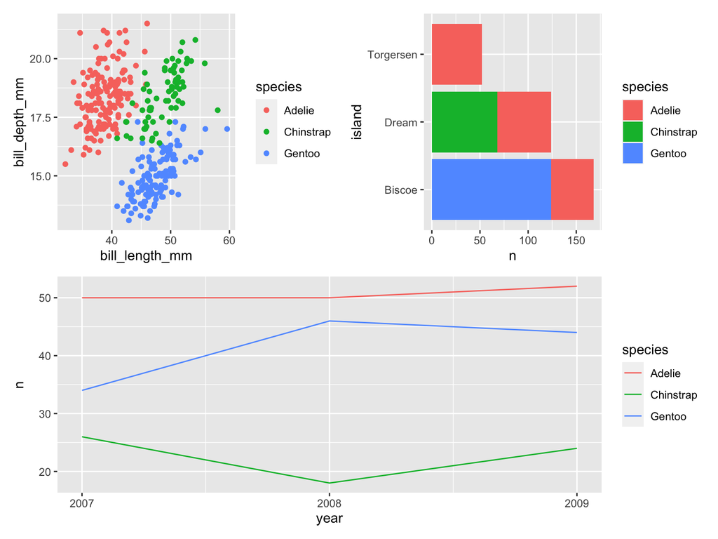

```r
(gg_penguin_scatter + gg_penguin_bar_chart ) / gg_penguins_timeline
```

To change the theme of all subplots we use `&`

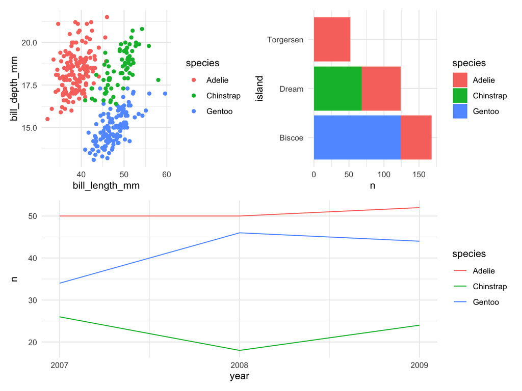

```r
ptwc_basic <- (gg_penguin_scatter + gg_penguin_bar_chart ) / gg_penguins_timeline

ptwc_basic & theme_minimal()
```

To collect together the legends we go through two steps:

- Remove the guides for the `color` aesthetic, leaving only the fill guide.
- Use `plot_layout(guides = "collect")` to collect the remaining guides together

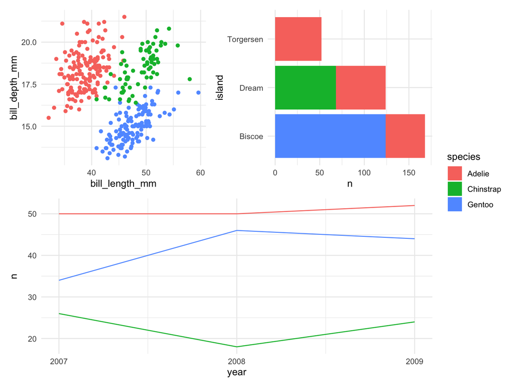

```r
ptchw_collected <- ( gg_penguin_scatter | gg_penguin_bar_chart ) / gg_penguins_timeline + plot_layout(guides = "collect")

ptchw_collected &
  guides(color = guide_none()) &
  theme_minimal()
```

{patchwork} can do automatic tagging, the documentation shows the different systems of counting available.

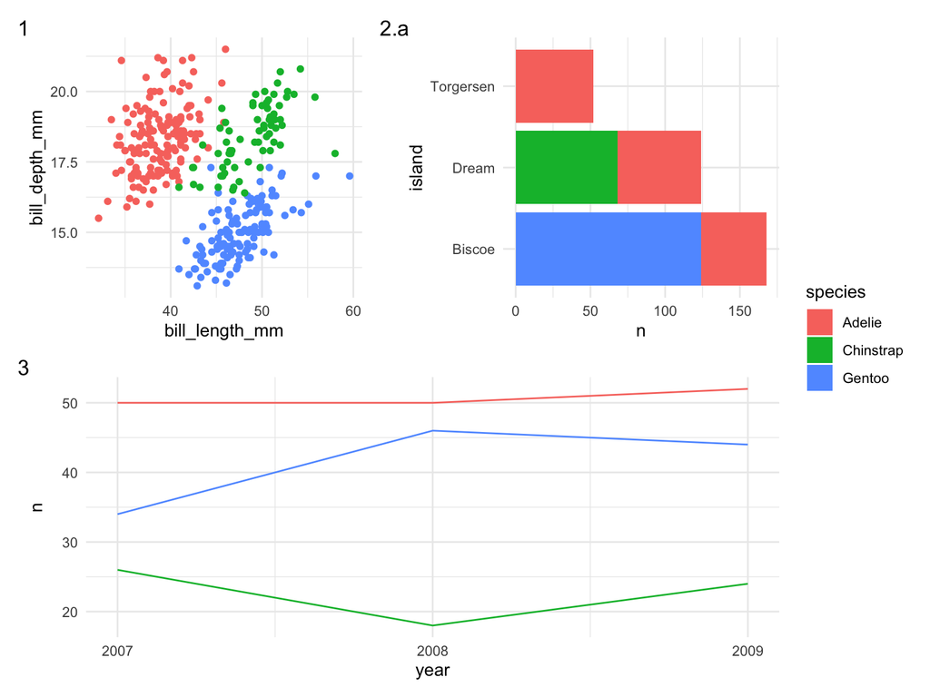

```r
ptchw_auto_tagging <- ( gg_penguin_scatter | gg_penguin_bar_chart + plot_layout(tag_level = 'new') ) / gg_penguins_timeline + plot_layout(guides = "collect")

ptchw_auto_tagging &
  guides(color = guide_none()) &
  plot_annotation(tag_levels = c('1', 'a'), tag_sep = ".") &
  theme_minimal()
```

Manual tagging

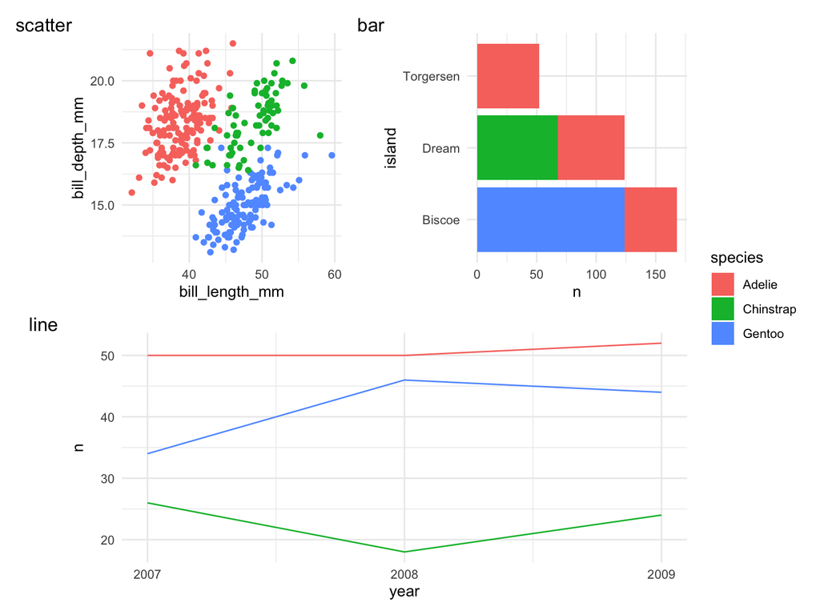

```r
ptchw_manual_tagging <- ( gg_penguin_scatter + labs(tag = "scatter") | gg_penguin_bar_chart + labs(tag = "bar") ) / gg_penguins_timeline + labs(tag = "line") + plot_layout(guides = "collect")


ptchw_manual_tagging &
  guides(color = guide_none()) &
  theme_minimal()
```